# 6_strings_catenary

```python
# Integer numbers.

a = 1
print(type(a))

a = -1
print(type(a))


# Real numbers (aka floats).

a = 1.0
print(type(a))


# Complex numbers.

a = 1.0j
print(type(a))

a = 2.0 + 1.0j
print(type(a))


# Convert between types.

a = int(1.0)
print(a)
print(type(a))

a = int(1.9)
print(a)

#a = float(1.0J)  # error

#a = float(2.0 + 0.0J)  # error


# Strings.

a = "hello"
print(type(a))


# String formatting I.  (Old style, for shorter strings.)

# Check out: pyformat.info

s = "Hello %d World." % (1)  # integer
print(s)

s = "Hello %d World"
print(s % (1))  # substitution is delayed

s = "Hello %d %d World." % (1,2)  # several substitutions
print(s)

n = 1
s = "Hello %d World." % (n)  # can use variable
print(s)

s = "Hello %3d World." % (1)  # number of digits
print(s)

s = "Hello %03d World." % (1)  # zero padding
print(s)

s = "Hello %f World." % (1.0)  # float
print(s)

s = "Hello %8.3f World." % (1.0)  # width and decimal places
print(s)

s = "Hello %s." % ("World")  # string
print(s)

s = "Hello %10s." % ("World")  # padded string
print(s)


# String formatting II.  (Used in Prof. Baldini's lecture notes.)

x = 2
y = 1.0
s = f"Hello {x:03d} {y:8.3f} World."
print(s)


# String formatting III.  (Useful for long strings.)

s = "Hello {1:03d} {0:8.3f} {1:03d} World.".format(1.0, 2)
print(s)

s = "Hello {name} {surname}.".format(name="William", surname="Shockley")
print(s)

d = {"name": "William", "surname": "Shockley"}  # dictionary
s = "Hello {name} {surname}.".format(**d)
print(s)


# Escaping.

s = "Hello\nWorld."
print(s)

s = r"Hello\nWorld."
print(s)

s = '''This is
an extended
piece of text.
'''
print(s)


# Strings to and from files.

f = open("hello.txt", "w")  # check that the folder is correct!
f.write("Hello World.")
f.close()

f = open("hello.txt", "r")
s = f.read()  # use readlines to save lines separately as list elements
f.close()
print(s)
```

```
<class 'int'>
<class 'int'>
<class 'float'>
<class 'complex'>
<class 'complex'>
1
<class 'int'>
1
<class 'str'>
Hello 1 World.
Hello 1 World
Hello 1 2 World.
Hello 1 World.
Hello   1 World.
Hello 001 World.
Hello 1.000000 World.
Hello    1.000 World.
Hello World.
Hello      World.
Hello 002    1.000 World.
Hello 002    1.000 002 World.
Hello William Shockley.
Hello William Shockley.
Hello
World.
Hello\nWorld.
This is
an extended
piece of text.

Hello World.
```

RIASSUNTO:

L'obiettivo di questa lezione è quello di valutare le varie possibilità di formattazione di stringhe e numeri (stampa della classe).

1. stampa delle classi dei numeri (int, float, complex):

a = ... print(type(a)) -> int, float, complex (per inciso, i complex si rendono aggiungendo una j alla fine del numero)

2. conversione da una classe all'altra

a = int(1.0) --> per esempio, questo comando converte un float nel suo corrispondente int print(a) print (type(a))

3. stampa della classe delle stringhe:

a = "..." print(type(a)) -> str

Le diverse formattazioni di stringhe sono basate sulle sostituzioni: 4. I formattazione di stringhe - "... %d ..." % (x) -> sostituisce x all'interno della frase, e x può essere un int, una variabile cui assegno un valore; - "... %f ..." % (x) -> x è un float - "... %s ..." % (x) -> x è una stringa - "... %d %d ..." % (x, y) -> fa più sostituzioni - s = "... %d ..." print (s % (x)) -> sostituzione posticipata - "... %3d ..." % (x) -> sostituisce x con un numero di "digits", cioè spazi, pari a 3 - "... %03d ..." % (x) -> aggiunge degli 0 prima di x - "... %8.3f ..." % (x) -> definisce la lunghezza della sostituzione (la prima cifra sono i digits, la seconda il numero di decimali)

5. II formattazione di stringhe:

x = ... y = ... s = f"... {x:03d} {y:8.3f} ..." -> sia per i numeri che per le variabili

6. III formattazione di stringhe:
   - "... {1:8.3f} {0:3d} {1:8.3f} ...".format(x, y) -> sostituisce 0 (x, che è il primo numero) e 1 (y, che è il secondo)
   - "... {name} {surname}".format(name = "...", surname = "...")
   - d = {"name" : "...", "surname" : "..."} s = "... {name} {surname}".format(**d) -> uso dei dizionari
7. andare a capo: \n
8. se si vuole leggere le cose come sono scritte, apporre r prima di ""
9. se si vuole leggere le cose come sono scritte con le andate a capo ecc., scrivere la stringa tra ''' e '''
10. aprire le stringhe da file:
    - f = open("... .txt", "w") -> scrive su un nuovo file f.write("...") f.close
    - f = open("... .txt", "r") -> legge da file s= f.read() f.close print(s)

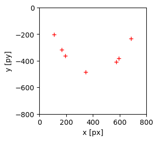

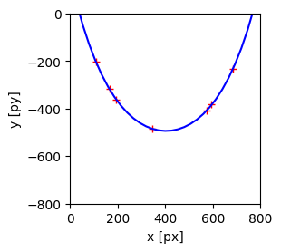

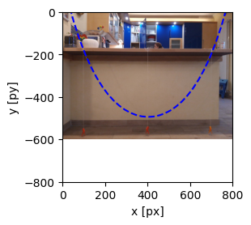

```python
# Esempio di codice per l'esperienza di laboratorio della catenaria.
# Consultare la traccia dell'esercitazione per una spiegazione completa.

import numpy as np
import matplotlib.pyplot as plt
import matplotlib
from scipy.optimize import curve_fit

# Produrre un file di testo che contenga le coordinate x e y, in pixel, di
# alcuni punti sulla fotografia della cordicella.  Una decina di punti è
# sufficiente ad ottenere un buon fit.
# Per identificare le coordinate in pixel è possibile, ad esempio, usare un
# editor di fotografie come Paint (su Windows) oppure GIMP (multipiattaforma).
# Solitamente, la posizione del cursore viene indicata come coppia di pixel
# in una barra di stato dell'interfaccia grafica.
# Notare che i pixel vengono contati da sinistra a destra e dall'alto in basso.
# Qui si assume che le colonne nel file di dati siano delimitate da virgole,
# quindi il file si dice "CSV" (comma-separated values).

dati = np.loadtxt("./catenaria.csv", delimiter=",")

# L'array dati contiene le posizioni x e y nella prima colonna (indice 0) e
# nella seconda colonna (indice 1), rispettivamente.  Per comodità, copiamo
# i valori in due array separati.  Il simbolo "due punti" serve a indicare
# tutte le righe dell'array.
# Conviene cambiare il segno ai pixel sull'asse y, in modo da ovviare al fatto
# che nelle foto vengono contati dall'alto in basso.  In questo modo, l'asse
# delle y diventa orientato dal basso in alto (come ci aspettiamo) con lo zero
# posizionato all'estremo superiore della figura.
px = dati[:,0]
py = -dati[:,1]

# Figura che mostra i dati raccolti.
fig = plt.figure(figsize=(3.0,3.0), frameon=True)
plt.axes([0.25,0.2,0.7,0.7])
plt.plot(px, py, "+r")
plt.xlim([0,800])
plt.ylim([-800,0])
plt.xlabel(r"x [px]")
plt.ylabel(r"y [py]")
plt.savefig("fit.png", dpi=300)

# Modello per il fit.
# Il primo argomento della funzione è la variabile indipendente, gli altri tre
# argomenti sono i parametri di fit.
def catenaria(x, a, c, x0):
    y = c + a * np.cosh((x - x0) / a)
    return y

# Valore di guess per il fit, che corrisponde all'ordine di grandezza atteso
# per i tre parametri di fit (a,c,x0).
# Se la foto ha una risoluzione molto alta, i pixel varieranno attorno al valore
# 1000, altrimenti attorno al valore 100.
p_guess = (100.0, 100.0, 100.0)

# La funzione curve_fit restituisce i valori ottimali dei parametri di fit
# nella variabile popt.
popt, pcov = curve_fit(catenaria, px, py, p_guess)

# Calcoliamo la funzione di fit su una griglia arbitraria di valori della
# variabile indipendente.  Ora dobbiamo passare alla funzione di fit
# i valori ottimizzati dei parametri di fit, che sono stati salvati nella
# variabile popt e sono accessibili come popt[0], popt[1], popt[2].
# Per calcolare la funzione "catenaria" su tutti i valori della variabile
# indipendente x, è possibile passare un array alla funzione (che
# automaticamente verrà eseguita per ogni elemento dell'array) oppure
# costruire un array di y iterando la variabile x su tutta la griglia di valori
# con un ciclo for.
xx = np.linspace(0.0,800.0, 31)
yy = catenaria(xx, popt[0], popt[1], popt[2])
# yy = np.array([catenaria(x, popt[0], popt[1], popt[2]) for x in xx])

# Aggiungiamo alla figura precedente la curva di fit.
fig = plt.figure(figsize=(3.0,3.0), frameon=True)
plt.axes([0.25,0.2,0.7,0.7])
plt.plot(px, py, "+r")
plt.plot(xx, yy, "-b")
plt.xlim([0,800])
plt.ylim([-800,0])
plt.xlabel(r"x [px]")
plt.ylabel(r"y [py]")
plt.savefig("fit.png", dpi=300)

# Possiamo anche produrre una figura che mostra all'interno degli assi la
# fotografia stessa che abbiamo usato per determinare le coordinate dei pixel.
# A questo scopo usiamo la funzione "imread" per acquisire la fotografia in
# una variabile ("foto").
# Poi, usiamo la funzione "imshow" per mostrare la figura sugli assi.
# E' necessario definire il parametro "extent" per indicare a imshow dove
# posizionare la foto all'interno degli assi.  I valori sono dati in pixel e
# corrispondono a (x_min, x_max, y_min, y_max).  L'estensione in pixel lungo
# i due assi deve corrispondere alla dimensione della foto (800x600 nel nostro
# caso).  La figura sarà posizionata a valori negativi dell'asse y perché
# l'asse y ha lo zero posto sul bordo superiore della foto (come discusso
# all'inizio dello script).
foto = matplotlib.image.imread("./catenaria.jpg")
fig = plt.figure(figsize=(3.0,3.0), frameon=True)
plt.axes([0.25,0.2,0.7,0.7])
plt.imshow(foto, extent=(0,800,-600,0))
plt.plot(xx, yy, "--b")
plt.xlim([0,800])
plt.ylim([-800,0])
plt.xlabel(r"x [px]")
plt.ylabel(r"y [py]")
plt.savefig("fit.png", dpi=300)

plt.show()
```